# InstaCart Exploratory Analysis: Users - 153479 & 44294

April Leclair, Daniel Ochoa, Hoang Anh Thai Vu, Qiuhan Sun

November 25, 2017

This document compares two users that were in the same category from the hierarchcal clustering analysis. We look at users with `user_id` == 153479 & 44294.

# Load the data

```r
orders <- read_csv("../Source/orders_sample.csv")
order_products <- read_csv("../Source/order_products_sample.csv")
products <- read_csv("../Source/products.csv")
departments <- read_csv("../Source/departments.csv")
aisles <- read_csv("../Source/aisles.csv")
```

```r
names(orders)
```

```
## [1] "order_id"               "user_id"
## [3] "eval_set"               "order_number"
## [5] "order_dow"              "order_hour_of_day"
## [7] "days_since_prior_order"
```

```r
names(order_products)
```

```
## [1] "order_id"          "product_id"        "add_to_cart_order"
## [4] "reordered"
```

```r
names(products)
```

```
## [1] "product_id"    "product_name"  "aisle_id"      "department_id"
```

```r
names(departments)
```

```
## [1] "department_id" "department"
```

```r
names(aisles)
```

```
## [1] "aisle_id" "aisle"
```

# Compare the buying patterns of 1000 random users who bought more than 2000 products: `user_id` == 153479 & 44294

## Prepare the data sets for each user

```r
user153479 <-
  orders %>%
  filter(user_id == 153479,
         eval_set == "prior") %>%
  left_join(order_products, by="order_id") %>%
  left_join(products, by="product_id")

user44294 <-
  orders %>%
  filter(user_id == 44294,
         eval_set == "prior") %>%
  left_join(order_products, by="order_id") %>%
  left_join(products, by="product_id")
```

## Conduct feature engineering

### Create a varable for discrete factored time of the day

```r
# new_levels <- c("Late Evening","Late Evening","Late Evening","Dawn","Dawn","Dawn","Dawn",
#                 "Morning","Morning","Morning","Morning","Morning",
#                 "Afternoon","Afternoon","Afternoon","Afternoon","Afternoon",
#                 "Evening","Evening","Evening","Evening",
#                 "Late Evening","Late Evening","Late Evening","Late Evening")
# user153479$timeofday <- factor(new_levels[user153479$order_hour_of_day])
# user153479$timeofday <- factor(user153479$order_hour_of_day, levels = c("Dawn", "Morning", "Afternoon", "Evening", "Late Evening"))
# user44294$timeofday <- factor(new_levels[user44294$order_hour_of_day])
# user44294$timeofday <- factor(user44294$timeofday, levels = c("Dawn", "Morning", "Afternoon", "Evening", "Late Evening"))
# rm(new_levels)
```

### Create a varable for continuous numeric time of the day

```r
user153479$timeofday_num <- as.numeric(user153479$order_hour_of_day)
user44294$timeofday_num <- as.numeric(user44294$order_hour_of_day)
```

### Create a varable for ordered factor day of the week

```r
levels(user153479$order_dow) <- c("Sunday", "Monday", "Tuesday", "Wednesday",
                                                 "Thursday", "Friday", "Saturday")
levels(user44294$order_dow) <- c("Sunday", "Monday", "Tuesday", "Wednesday",
                                                 "Thursday", "Friday", "Saturday")
```

## Visualize discrete day of the week

These users do not look that similar just by looking at the `days_since_prior_order` by `day of the week` plot. However, the plots reflect order chronology that the cluster data did not take into account.

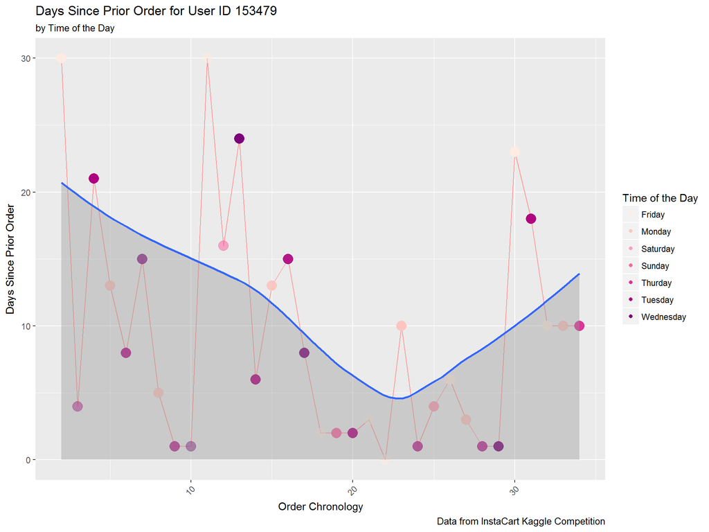

```r
is.na(user153479$days_since_prior_order) <- 0
user153479 %>%
  na.omit() %>%
  ggplot(aes(x=order_number, y=days_since_prior_order)) +
  geom_line(color="#FF9999") +
  geom_point(aes(size = 0.5, alpha = 0.25, color=order_dow)) +
  scale_color_brewer(palette = "RdPu") +
  guides(size=FALSE, alpha=FALSE) +
  geom_smooth(stat="smooth", position="stack", method="loess") +
  theme(axis.text.x=element_text(angle=45,hjust=1)) +
  labs(title="Days Since Prior Order for User ID 153479",
       subtitle="by Time of the Day",
       color="Time of the Day",
       size="Size",
       x="Order Chronology", y="Days Since Prior Order",
       caption="Data from InstaCart Kaggle Competition")
```

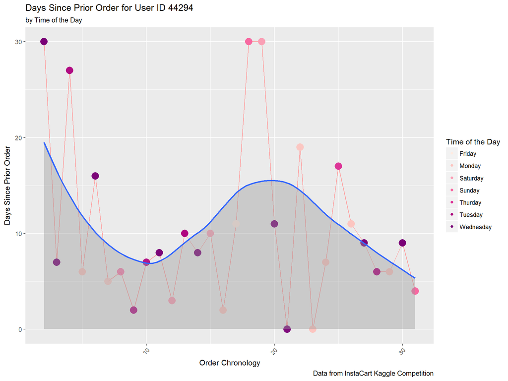

```r
user44294 %>%
  na.omit() %>%
  ggplot(aes(x=order_number, y=days_since_prior_order)) +
  geom_line(color="#FF9999") +
  geom_point(aes(size = 0.5, alpha = 0.25, color=order_dow)) +
  scale_color_brewer(palette = "RdPu") +
  guides(size=FALSE, alpha=FALSE) +
  geom_smooth(stat="smooth", position="stack", method="loess") +
  theme(axis.text.x=element_text(angle=45,hjust=1)) +
  labs(title="Days Since Prior Order for User ID 44294",
       subtitle="by Time of the Day",
       color="Time of the Day",
       size="Size",
       x="Order Chronology", y="Days Since Prior Order",
       caption="Data from InstaCart Kaggle Competition")
```